# U.S. storm population harm and economic impact

Andreas Manuth

#Introduction The basic goal of this assignment is to explore the NOAA Storm Database and answer some basic questions about severe weather events, esp.: 1. Across the United States, which types of events are most harmful with respect to population health? 2. Across the United States, which types of events have the greatest economic consequences? The intended audience are government or municipal manager who might be responsible for preparing for severe weather events and will need to prioritize resources for different types of events. However, this report does not make any specific recommendations.

#Data Processing As a standard tool set for data science the library tidyverse is loaded and setup to run before any chunk of code herein:

```r
library(tidyverse)
library(stringdist)
```

The analysis is based on the data from U.S. National Oceanic and Atmospheric Administration’s (NOAA) storm database made available as a comma-separated-value file compressed via the bzip2 algorithm to reduce its size at https://d396qusza40orc.cloudfront.net/repdata%2Fdata%2FStormData.csv.bz2 Loading the first 1000 entries - unfortunately the current hardware can’t deal with it all at once - for a first overview is done by:

```r
# Download 1st, because read_csv() does not un-compress remote bz2 files.
# The if-clauses are to prevent time consuming execution, when it is not needed.
if (!file.exists("repdata_data_StormData.csv.bz2"))
    download.file("https://d396qusza40orc.cloudfront.net/repdata%2Fdata%2FStormData.csv.bz2",
                  "repdata_data_StormData.csv.bz2")
if (!exists("storm_data")) storm_data <- read_csv("repdata_data_StormData.csv.bz2", n_max = 1000)
summary(storm_data)
```

[output not shown]

Some of the variables are defined at: - National Weather Service Storm Data Documentation https://d396qusza40orc.cloudfront.net/repdata%2Fpeer2_doc%2Fpd01016005curr.pdf This describes the types of events and how the events are described in the data. Unfortunately a formal definition of the event properties is not given.  
- National Climatic Data Center Storm Events FAQ https://d396qusza40orc.cloudfront.net/repdata%2Fpeer2_doc%2FNCDC%20Storm%20Events-FAQ%20Page.pdf provides information about fatality codes, the Saffir-Simpson hurrican scale and some more details. For completeness of the report repository they are downloaded as well:

```r
download.file("https://d396qusza40orc.cloudfront.net/repdata%2Fpeer2_doc%2Fpd01016005curr.pdf",
              "repdata_peer2_doc_pd01016005curr.pdf")
```

```
versuche URL 'https://d396qusza40orc.cloudfront.net/repdata%2Fpeer2_doc%2Fpd01016005curr.pdf'
==================================================
```

```r
download.file("https://d396qusza40orc.cloudfront.net/repdata%2Fpeer2_doc%2FNCDC%20Storm%20Events-FAQ%20Page.pdf",
              "repdata_peer2_doc_NCDC Storm Events-FAQ Page.pdf")
```

```
versuche URL 'https://d396qusza40orc.cloudfront.net/repdata%2Fpeer2_doc%2FNCDC%20Storm%20Events-FAQ%20Page.pdf'
==================================================
```

Now read all the data in the columns of interest and get the complete overview:

```r
storm_data <- read_csv("repdata_data_StormData.csv.bz2",
                       col_types = cols_only(EVTYPE = col_character(),
                                             FATALITIES = col_double(),
                                             INJURIES = col_double(),
                                             PROPDMG = col_double(),
                                             PROPDMGEXP = col_character(),
                                             CROPDMG = col_double(),
                                             CROPDMGEXP = col_character(),
                                             # spec() says col_logical, but there are "k" etc.
                                             REFNUM = col_double()))
summary(storm_data)
```

```
    EVTYPE            FATALITIES          INJURIES            PROPDMG
 Length:902297      Min.   :  0.0000   Min.   :   0.0000   Min.   :   0.00
 Class :character   1st Qu.:  0.0000   1st Qu.:   0.0000   1st Qu.:   0.00
 Mode  :character   Median :  0.0000   Median :   0.0000   Median :   0.00
                    Mean   :  0.0168   Mean   :   0.1557   Mean   :  12.06
                    3rd Qu.:  0.0000   3rd Qu.:   0.0000   3rd Qu.:   0.50
                    Max.   :583.0000   Max.   :1700.0000   Max.   :5000.00
  PROPDMGEXP           CROPDMG         CROPDMGEXP            REFNUM
 Length:902297      Min.   :  0.000   Length:902297      Min.   :     1
 Class :character   1st Qu.:  0.000   Class :character   1st Qu.:225575
 Mode  :character   Median :  0.000   Mode  :character   Median :451149
                    Mean   :  1.527                      Mean   :451149
                    3rd Qu.:  0.000                      3rd Qu.:676723
                    Max.   :990.000                      Max.   :902297
```

According to descriptions the events in the database start in the year 1950 and end in November 2011. In the earlier years of the database there are generally fewer events recorded, most likely due to a lack of good records. More recent years should be considered more complete. The higher weight of recent years given by that may also bring a focus on recent events taking account trends like climate heating.  
The event types in the data are, e.g.:

```r
event_types <- unique(storm_data$EVTYPE)
head(event_types)
```

```
[1] "TORNADO"               "TSTM WIND"             "HAIL"
[4] "FREEZING RAIN"         "SNOW"                  "ICE STORM/FLASH FLOOD"
```

```r
tail(event_types)
```

```
[1] "DENSE SMOKE"              "LAKESHORE FLOOD"          "MARINE THUNDERSTORM WIND"
[4] "MARINE STRONG WIND"       "ASTRONOMICAL LOW TIDE"    "VOLCANIC ASHFALL"
```

```r
print("Fatalities:")
```

```
[1] "Fatalities:"
```

```r
summary(storm_data$FATALITIES)
```

```
    Min.  1st Qu.   Median     Mean  3rd Qu.     Max.
  0.0000   0.0000   0.0000   0.0168   0.0000 583.0000
```

```r
print("Injuries:")
```

```
[1] "Injuries:"
```

```r
summary(storm_data$INJURIES)
```

```
     Min.   1st Qu.    Median      Mean   3rd Qu.      Max.
   0.0000    0.0000    0.0000    0.1557    0.0000 1700.0000
```

The impact on population health is measured in terms of FATALITIES and INJURIES as numbers. The economic impact seem to be measured by PROPDMG, PROPDMGEXP, CROPDMG, CROPDMGEXP. As they are poorly documented we first look into the …EXP variables:

```r
print(c("PROPDMGEXP values: ", unique(storm_data$PROPDMGEXP)))
```

```
 [1] "PROPDMGEXP values: " "K"                   "M"                   NA
 [5] "B"                   "m"                   "+"                   "0"
 [9] "5"                   "6"                   "?"                   "4"
[13] "2"                   "3"                   "h"                   "7"
[17] "H"                   "-"                   "1"                   "8"
```

```r
print(c("CROPDMGEXP values: ", unique(storm_data$CROPDMGEXP)))
```

```
 [1] "CROPDMGEXP values: " NA                    "M"                   "K"
 [5] "m"                   "B"                   "?"                   "0"
 [9] "k"                   "2"
```

I assume that C/PROPDMGEXP is the exponent to the base of 10 of the values given in C/PROPDMG. Non-numeric characters are assumed to be interpreted like this: - H / h = 2 - K = 3 - M / m = 6 - B = 9 - NA / + / ? / - = 0  
For the computation of property damages this interpretation is coded into a function and then added to the storm data:

```r
damage <- function(significand, order_of_magnitude){
    order_of_magnitude <- if (is.numeric(order_of_magnitude)) order_of_magnitude # no need to convert
    else # strange values are ignored
        if (is.na(order_of_magnitude) || str_detect(as.character(order_of_magnitude), "[:punct:]"))
            order_of_magnitude <- 0
        else { # handling of common abbreviations
            order_of_magnitude <- str_to_lower(order_of_magnitude)
            if (order_of_magnitude == "h") order_of_magnitude <- 2
            else if (order_of_magnitude == "k") order_of_magnitude <- 3
            else if (order_of_magnitude == "m") order_of_magnitude <- 6
            else if (order_of_magnitude == "b") order_of_magnitude <- 9
            else order_of_magnitude <- NaN # unrecognized characters result in strange values
        }
    significand * 10^order_of_magnitude
}
storm_data <- mutate(storm_data,
                     propdmg_unified = damage(PROPDMG, PROPDMGEXP),
                     cropdmg_unified = damage(CROPDMG, CROPDMGEXP))
```

[output not shown]

```r
print("Property Damage:")
```

```
[1] "Property Damage:"
```

```r
summary(storm_data$propdmg_unified)
```

```
   Min. 1st Qu.  Median    Mean 3rd Qu.    Max.
      0       0       0   12063     500 5000000
```

```r
print("Crop Damage:")
```

```
[1] "Crop Damage:"
```

```r
summary(storm_data$cropdmg_unified)
```

```
   Min. 1st Qu.  Median    Mean 3rd Qu.    Max.
  0.000   0.000   0.000   1.527   0.000 990.000
```

```r
storm_data <- mutate(storm_data, EVTYPE = str_to_upper(EVTYPE))
event_damage <- group_by(storm_data, EVTYPE)
totals <- summarize(event_damage,
                    fatalities = sum(FATALITIES),
                    injuries = sum(INJURIES),
                    propdmg = sum(propdmg_unified),
                    cropdmg = sum(cropdmg_unified))
summary(totals)
```

```
    EVTYPE            fatalities         injuries          propdmg
 Length:890         Min.   :   0.00   Min.   :    0.0   Min.   :0.000e+00
 Class :character   1st Qu.:   0.00   1st Qu.:    0.0   1st Qu.:0.000e+00
 Mode  :character   Median :   0.00   Median :    0.0   Median :0.000e+00
                    Mean   :  17.02   Mean   :  157.9   Mean   :1.223e+07
                    3rd Qu.:   0.00   3rd Qu.:    0.0   3rd Qu.:5.000e+04
                    Max.   :5633.00   Max.   :91346.0   Max.   :3.212e+09
    cropdmg
 Min.   :     0
 1st Qu.:     0
 Median :     0
 Mean   :  1548
 3rd Qu.:     0
 Max.   :579596
```

```r
head(totals)
```

| EVTYPE | fatalities | injuries | propdmg | cropdmg |
| --- | --- | --- | --- | --- |
| ? | 0 | 0 | 5000 | 0.00 |
| ABNORMAL WARMTH | 0 | 0 | 0 | 0.00 |
| ABNORMALLY DRY | 0 | 0 | 0 | 0.00 |
| ABNORMALLY WET | 0 | 0 | 0 | 0.00 |
| ACCUMULATED SNOWFALL | 0 | 0 | 0 | 0.00 |
| AGRICULTURAL FREEZE | 0 | 0 | 0 | 28.82 |

```r
tail(totals)
```

| EVTYPE | fatalities | injuries | propdmg | cropdmg |
| --- | --- | --- | --- | --- |
| WINTER WEATHER | 33 | 398 | 11974900 | 15 |
| WINTER WEATHER MIX | 0 | 68 | 60000 | 0 |
| WINTER WEATHER/MIX | 28 | 72 | 4873500 | 0 |
| WINTERY MIX | 0 | 0 | 0 | 0 |
| WINTRY MIX | 1 | 77 | 12500 | 0 |
| WND | 0 | 0 | 0 | 0 |

The tail end shows that there are event types without any damage, which are extracted for concise summary and further analysis of the harmful types:

```r
harmless_events <- select(filter(totals,
                                 fatalities == 0 & injuries == 0 & propdmg == 0 & cropdmg == 0),
                          EVTYPE)
harmful_events <- filter(totals, fatalities != 0 | injuries != 0 | propdmg != 0 | cropdmg != 0)
summary(harmful_events)
```

```
    EVTYPE            fatalities         injuries          propdmg             cropdmg
 Length:444         Min.   :   0.00   Min.   :    0.0   Min.   :0.000e+00   Min.   :     0
 Class :character   1st Qu.:   0.00   1st Qu.:    0.0   1st Qu.:2.000e+03   1st Qu.:     0
 Mode  :character   Median :   0.00   Median :    0.0   Median :5.000e+04   Median :     0
                    Mean   :  34.11   Mean   :  316.5   Mean   :2.451e+07   Mean   :  3103
                    3rd Qu.:   2.00   3rd Qu.:    2.0   3rd Qu.:5.000e+05   3rd Qu.:     5
                    Max.   :5633.00   Max.   :91346.0   Max.   :3.212e+09   Max.   :579596
```

```r
head(harmful_events, 10)
```

| EVTYPE | fatalities | injuries | propdmg | cropdmg |
| --- | --- | --- | --- | --- |
| ? | 0 | 0 | 5000 | 0.00 |
| AGRICULTURAL FREEZE | 0 | 0 | 0 | 28.82 |
| APACHE COUNTY | 0 | 0 | 5000 | 0.00 |
| ASTRONOMICAL HIGH TIDE | 0 | 0 | 933500 | 0.00 |
| ASTRONOMICAL LOW TIDE | 0 | 0 | 320000 | 0.00 |
| AVALANCE | 1 | 0 | 0 | 0.00 |
| AVALANCHE | 224 | 170 | 1623900 | 0.00 |
| BEACH EROSION | 0 | 0 | 100000 | 0.00 |
| BLACK ICE | 1 | 24 | 0 | 0.00 |
| BLIZZARD | 101 | 805 | 25318480 | 172.00 |

```r
harmful_events <- mutate(harmful_events, event_phonetic = phonetic(EVTYPE))
harmful_phonetic<- group_by(harmful_events, event_phonetic)
harmful_totals <- summarize(harmful_phonetic,
                            event_type = EVTYPE[1],
                            fatalities = sum(fatalities),
                            injuries = sum(injuries),
                            propdmg = sum(propdmg),
                    cropdmg = sum(cropdmg))
summary(harmful_totals)
```

```
 event_phonetic      event_type          fatalities         injuries           propdmg
 Length:162         Length:162         Min.   :   0.00   Min.   :    0.00   Min.   :0.000e+00
 Class :character   Class :character   1st Qu.:   0.00   1st Qu.:    0.00   1st Qu.:5.000e+03
 Mode  :character   Mode  :character   Median :   1.00   Median :    1.00   Median :1.973e+05
                                       Mean   :  93.49   Mean   :  867.46   Mean   :6.719e+07
                                       3rd Qu.:   9.50   3rd Qu.:   34.75   3rd Qu.:1.934e+06
                                       Max.   :5658.00   Max.   :91368.00   Max.   :3.215e+09
    cropdmg
 Min.   :     0.0
 1st Qu.:     0.0
 Median :     0.0
 Mean   :  8505.1
 3rd Qu.:    53.8
 Max.   :579686.3
```

```r
head(harmful_totals)
```

| event_phonetic | event_type | fatalities | injuries | propdmg | cropdmg |
| --- | --- | --- | --- | --- | --- |
| ?000 | ? | 0 | 0 | 5000 | 0.00 |
| A122 | APACHE COUNTY | 0 | 0 | 5000 | 0.00 |
| A145 | AVALANCE | 225 | 170 | 1623900 | 0.00 |
| A236 | ASTRONOMICAL HIGH TIDE | 0 | 0 | 1253500 | 0.00 |
| A262 | AGRICULTURAL FREEZE | 0 | 0 | 0 | 28.82 |
| B262 | BEACH EROSION | 0 | 0 | 100000 | 0.00 |

```r
tail(harmful_totals)
```

| event_phonetic | event_type | fatalities | injuries | propdmg | cropdmg |
| --- | --- | --- | --- | --- | --- |
| W532 | WIND STORM | 2 | 1 | 446500 | 5.50 |
| W534 | WIND/HAIL | 0 | 0 | 500 | 0.00 |
| W535 | WIND AND WAVE | 0 | 0 | 88000 | 55.00 |
| W536 | WINTER STORM | 279 | 1968 | 150201490 | 2498.99 |
| W645 | WHIRLWIND | 1 | 0 | 12000 | 0.00 |
| W653 | WARM WEATHER | 0 | 2 | 0 | 0.00 |

## Human Harm

There are 90that caused deaths and 84 that caused injuries. These are plotted here on logarithmic scales (TORNADO is much bigger than the others) and then listed sorted descending first by deaths than by injured:

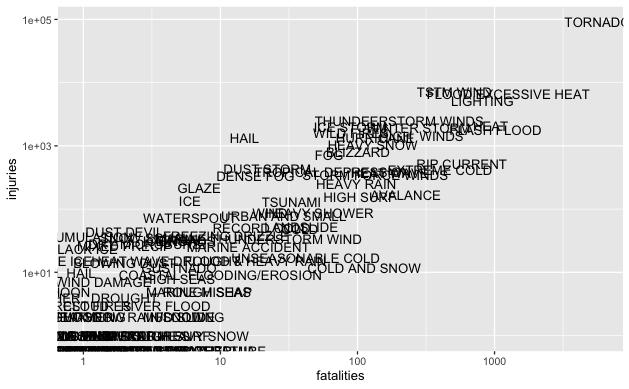

```r
humans_harmed <- arrange(filter(harmful_totals, fatalities != 0 | injuries != 0),
                         desc(fatalities), desc(injuries))
ggplot(humans_harmed, aes(fatalities, injuries)) +
    geom_text(aes(label = event_type)) + scale_x_log10() + scale_y_log10()
```

```r
print(humans_harmed)
```

| event_phonetic | event_type | fatalities | injuries | propdmg | cropdmg |
| --- | --- | --- | --- | --- | --- |
| T653 | TORNADO | 5658 | 91368 | 3214533960 | 100029.22 |
| E221 | EXCESSIVE HEAT | 1905 | 6548 | 3395000 | 636.40 |
| F421 | FLASH FLOOD | 1018 | 1785 | 1455199650 | 185056.51 |
| H300 | HEAT | 937 | 2100 | 298500 | 662.70 |
| L235 | LIGHTING | 817 | 5232 | 603434780 | 3580.61 |
| R126 | RIP CURRENT | 577 | 529 | 163000 | 0.00 |
| T235 | TSTM WIND | 510 | 7056 | 1345048710 | 113559.25 |
| F430 | FLOOD | 470 | 6789 | 899938480 | 168037.88 |
| E236 | EXTREME COLD | 400 | 415 | 11121650 | 6213.14 |
| H253 | HIGH WINDS | 293 | 1471 | 381866160 | 21057.81 |

[output cut: 95 more lines]

As the event types cluster around the diagonal it seems sensible to concentrate on event types with high death toll as these come with high injuries, too.

##Damage There are 132that caused property damage and 60 that caused crop damage. These are plotted below and listed sorted descending first by damage to property than by crop:

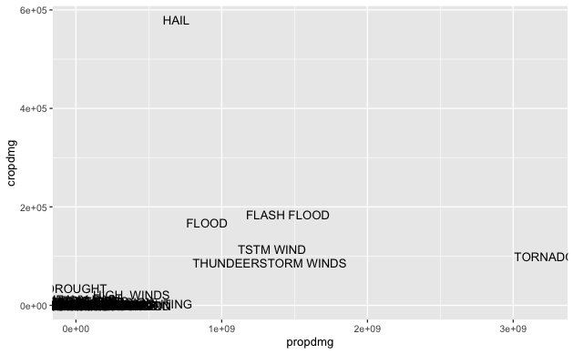

```r
cash_dmg <- arrange(filter(harmful_totals, propdmg != 0 | cropdmg != 0),
                         desc(propdmg), desc(cropdmg))
ggplot(cash_dmg, aes(propdmg, cropdmg)) +
    geom_text(aes(label = event_type))
```

```r
print(cash_dmg)
```

| event_phonetic | event_type | fatalities | injuries | propdmg | cropdmg |
| --- | --- | --- | --- | --- | --- |
| T653 | TORNADO | 5658 | 91368 | 3214533960 | 100029.22 |
| F421 | FLASH FLOOD | 1018 | 1785 | 1455199650 | 185056.51 |
| T235 | TSTM WIND | 510 | 7056 | 1345048710 | 113559.25 |
| T536 | THUNDEERSTORM WINDS | 202 | 2453 | 1328985550 | 85734.93 |
| F430 | FLOOD | 470 | 6789 | 899938480 | 168037.88 |
| H400 | HAIL | 15 | 1361 | 688845780 | 579686.28 |
| L235 | LIGHTING | 817 | 5232 | 603434780 | 3580.61 |
| H253 | HIGH WINDS | 293 | 1471 | 381866160 | 21057.81 |
| W536 | WINTER STORM | 279 | 1968 | 150201490 | 2498.99 |
| W431 | WILD FIRES | 90 | 1606 | 125148290 | 9065.74 |

[output cut: 128 more lines]

Clearly the first six on the list have the biggest impact on property and crops.